# mutipleRNA

Xiaoying Wang

2021/11/15

## Read data and integrated multipleRNA

For this tutorial, we will be analyzing a dataset of GSM2230761_mouse1. We start by reading the data. For each scRNA count matrix, we read the .csv file from given path, and remove the gene if the value in the gene with more than min_cell cell is equal to zero, returning a Seurat object. DeepMAPS will remove outlier cells automatically. We will identify if a cell is an outlier based on the scRNA count matrix. And the outlier cells will be removed in the Seurat object.

## Integration of multiple scRNA-seq

We integrate the scRNA-seq by Seurat to obtain the integrated matrix which is the input of run_HGT(). ifnb.list is a list with multiple Seurat objects.

```r
#input:
#  ifnb.list: a list with multiple seurat objects
#output:
#  object : a seurat object with a integrated matrix
obj <- integratedRNA(ifnb.list)
```

## Perform heterogeneous graph transformer (HGT) model on integrated matrix

Next, we apply HGT, a deep learning framework on the GAS matrix. Four folders (cell, gene, model, att) need to be built in result_dir path. For multipleRNA data, the data_type should be set “multipleRNA”, and the joint embedding of gene and cell from HGT will be saved in result_dir path/gene (/cell). The attention of a gene to a cell is stored in result_dir/att, and the trained model is stored in result_dir/model. All the results are stored in R variable as a list HGT_result. The parameters in deep learning are set as default. The lr, n_hid, n_heads,epoch can be changed by users. The introduction of each parameter in deep learning are provide in Tutorial_install_package. The results are different with different GPUs. If you want to reproduce the result, please use [DeepMAPS server](https://bmblx.bmi.osumc.edu/).

```r
# required package -- reticulate
#input:
#  GAS: the spliced and normalized matrix obtained from CLR function
#  result_dir: The address for storing the models and optimization results(Type:str)
#  epoch:(Type:int)
#  lr: learning rate(Type:float)
#  n_hid: Number of hidden dimension(Type:int)
#  n_heads: Number of attention head(Type:int)
#  cuda: 0 use GPU0 else cpu(Type:int)
#  data_type: 'CITE', 'RNA_ATAC', or 'multiple RNA'
#  envPath: The address for environment to use
#output:
#  HGT_result: a list containing requried results of HGT model as follows:
#  parameters: given parameters from user --epoch, lr, n_hid, n_heads, cuda
#  cell_hgt_matrix: cell embedding matrix
#  feature_hgt_matrix : gene embedding matrix and protein embedding matrix when data_type is 'CITE';
#  attention: attention meassage for features and cells
#  data_type: 'CITE', 'RNA_ATAC', or 'multipleRNA'
#  result_dir: The address for storing the models and optimization results
#  GAS: the spliced and normalized matrix obtained from CLR function

HGT_result <- run_HGT(GAS = as.matrix(obj@assays$integrated@data),result_dir='/home/wan268/hgt/RNA_RNA/', data_type='multipleRNA',epoch=100)
```

## Cluster the cells

After running the HGT model, DeepMAPS applies Louvain a graph-based model to cluster cells based on the cell feature reduction matrix which returns from HGT model (stored in HGT_result[[‘cell_hgt_matrix’]]).

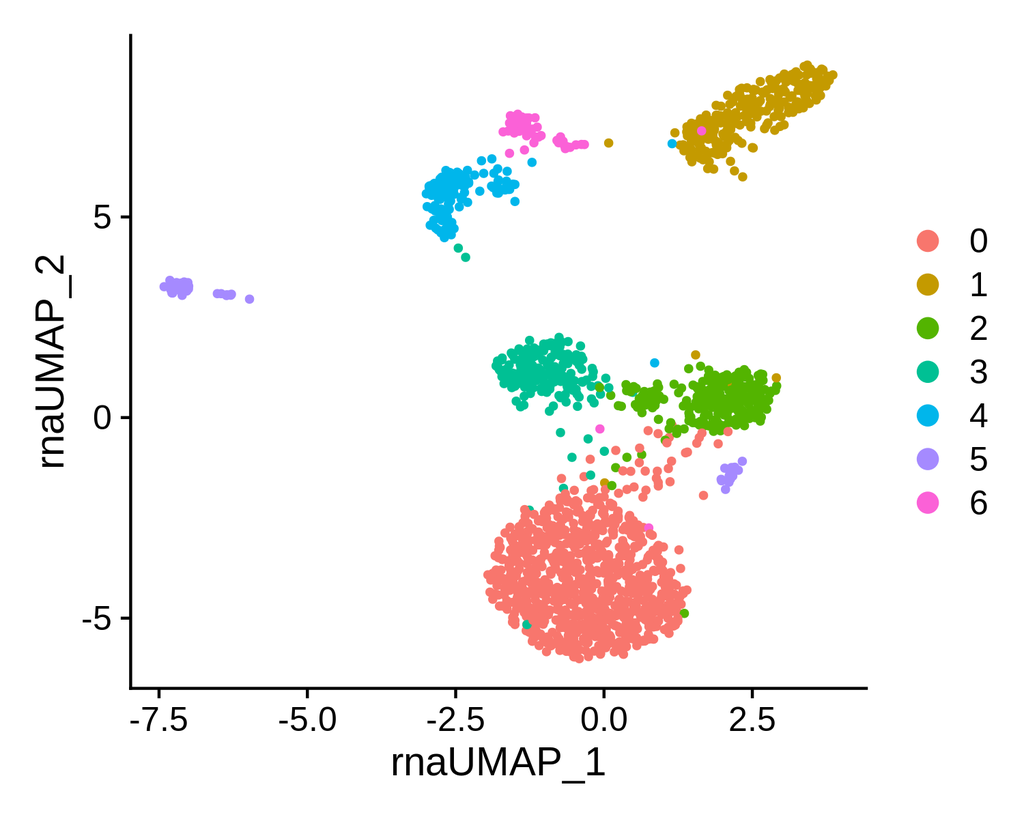

```r
DefaultAssay(obj) <- "integrated"
#define cell_embedding matrix
cell_hgt_matrix <- HGT_result[['cell_hgt_matrix']]
#cell_hgt_matrix <- as.matrix(cell_hgt_matrix)
rownames(cell_hgt_matrix) <- colnames(obj@assays$integrated@data)

obj <- obj[, colnames(obj@assays$integrated@data)]
cell_hgt_matrix <- cell_hgt_matrix[colnames(obj@assays$integrated@data),]

HGT_embedding <-
  CreateDimReducObject(embeddings = cell_hgt_matrix,
                       key = "HGT_",
                       assay = "RNA")
obj@reductions[['HGT']] <- HGT_embedding
obj <-
  FindVariableFeatures(obj, selection.method = "vst", nfeatures = 2000)
obj <- ScaleData(obj, features = VariableFeatures(obj))
obj <-
  RunUMAP(
    obj,
    reduction = 'HGT',
    dims = 1:ncol(cell_hgt_matrix),
    reduction.name = "umap.rna",
    reduction.key = "rnaUMAP_"
  )
obj <-
  FindNeighbors(obj,
                reduction = "HGT",
                dims = 1:ncol(cell_hgt_matrix))
obj <- FindClusters(obj, resolution = 0.5, graph.name = "RNA_snn")

DefaultAssay(obj) <- "RNA"

DimPlot(obj, reduction = 'umap.rna')
```

## Calculate cell cluster active gene modules

```r
# CT active gene modules calculation
#input:
#  GAS: mutipleRNA integrated matrix with gene * cell
#  cell_hgt_matrix: cell-embedding matrix which obtained from HGT function
#  att: attention matrix with gene-cell * head which obtain from HGT function
#output:
#  co : a biological gene module. a list with name CT-i and active gene list in CT-i

co <- get_gene_module(GAS = obj@assays$integrated@data, att = HGT_result[['attention']],method = 'SFP' )
```